# TAE - Unit 2 - Lecture 2

GT

April 21, 2016

## Unit 2 - Lecture 2 - Moneyball

Moneyball tells the story of the Oakland A’s. The A’s is a baseball team near San Francisco, California. They were once a rich team, but the team was purchased in 1995 by owners who enforced strict budget cuts. In 2002, the A’s lost three key players. By taking an analytics approach, they were able to find underevalued players and form teams that were very efficient. The A’s selected players based on their statistics.

### Making it to the Playoffs

The goal of a baseball team is to make the playoffs.

- How we can predict wheter or not a team make the playoffs by knowning how many games they won in the regular season.
- Use linear regression to predict how many games a team will win using the difference between runs scored and runs allowed.
- Use linear regression to predict the number of runs a team will score using batting statistics and the number of runs a team will allow using fielding and pitching statistics

First question: How many games does a time need to win in the regular season to make it to the playoff ?

In moneyball, Paul DePodesta judged that it would take 95 wins for the A’s to make it to the playoffs.

How does a team win games ?

They score more runs than their opponent does. The A’s calculated that they need to score 135 more runs than they allowed during the regular season to expect to win 95 games.

Let’s see if we can verify this using linear regression in R.

```r
baseball = read.csv("baseball.csv")
str(baseball)
```

```
## 'data.frame':    1232 obs. of  15 variables:
##  $ Team        : Factor w/ 39 levels "ANA","ARI","ATL",..: 2 3 4 5 7 8 9 10 11 12 ...
##  $ League      : Factor w/ 2 levels "AL","NL": 2 2 1 1 2 1 2 1 2 1 ...
##  $ Year        : int  2012 2012 2012 2012 2012 2012 2012 2012 2012 2012 ...
##  $ RS          : int  734 700 712 734 613 748 669 667 758 726 ...
##  $ RA          : int  688 600 705 806 759 676 588 845 890 670 ...
##  $ W           : int  81 94 93 69 61 85 97 68 64 88 ...
##  $ OBP         : num  0.328 0.32 0.311 0.315 0.302 0.318 0.315 0.324 0.33 0.335 ...
##  $ SLG         : num  0.418 0.389 0.417 0.415 0.378 0.422 0.411 0.381 0.436 0.422 ...
##  $ BA          : num  0.259 0.247 0.247 0.26 0.24 0.255 0.251 0.251 0.274 0.268 ...
##  $ Playoffs    : int  0 1 1 0 0 0 1 0 0 1 ...
##  $ RankSeason  : int  NA 4 5 NA NA NA 2 NA NA 6 ...
##  $ RankPlayoffs: int  NA 5 4 NA NA NA 4 NA NA 2 ...
##  $ G           : int  162 162 162 162 162 162 162 162 162 162 ...
##  $ OOBP        : num  0.317 0.306 0.315 0.331 0.335 0.319 0.305 0.336 0.357 0.314 ...
##  $ OSLG        : num  0.415 0.378 0.403 0.428 0.424 0.405 0.39 0.43 0.47 0.402 ...
```

THis dataset includes an observation for every team and year pair from 1962 to 2012 for all seasons with 162 games.

Since we’re confirming the claims made in Moneyball we want to build models using Paul DePodesta data had in 2002, let’s subsetting the data.

```r
moneyball = subset(baseball, Year < 2002)
str(moneyball)
```

```
## 'data.frame':    902 obs. of  15 variables:
##  $ Team        : Factor w/ 39 levels "ANA","ARI","ATL",..: 1 2 3 4 5 7 8 9 10 11 ...
##  $ League      : Factor w/ 2 levels "AL","NL": 1 2 2 1 1 2 1 2 1 2 ...
##  $ Year        : int  2001 2001 2001 2001 2001 2001 2001 2001 2001 2001 ...
##  $ RS          : int  691 818 729 687 772 777 798 735 897 923 ...
##  $ RA          : int  730 677 643 829 745 701 795 850 821 906 ...
##  $ W           : int  75 92 88 63 82 88 83 66 91 73 ...
##  $ OBP         : num  0.327 0.341 0.324 0.319 0.334 0.336 0.334 0.324 0.35 0.354 ...
##  $ SLG         : num  0.405 0.442 0.412 0.38 0.439 0.43 0.451 0.419 0.458 0.483 ...
##  $ BA          : num  0.261 0.267 0.26 0.248 0.266 0.261 0.268 0.262 0.278 0.292 ...
##  $ Playoffs    : int  0 1 1 0 0 0 0 0 1 0 ...
##  $ RankSeason  : int  NA 5 7 NA NA NA NA NA 6 NA ...
##  $ RankPlayoffs: int  NA 1 3 NA NA NA NA NA 4 NA ...
##  $ G           : int  162 162 162 162 161 162 162 162 162 162 ...
##  $ OOBP        : num  0.331 0.311 0.314 0.337 0.329 0.321 0.334 0.341 0.341 0.35 ...
##  $ OSLG        : num  0.412 0.404 0.384 0.439 0.393 0.398 0.427 0.455 0.417 0.48 ...
```

In order to build a linear regression equation to predict wins using the difference between runs scored and runs allowed, we’ll create a new variable called, ‘RD’ for Run Difference.

```r
moneyball$RD = moneyball$RS - moneyball$RA
str(moneyball)
```

```
## 'data.frame':    902 obs. of  16 variables:
##  $ Team        : Factor w/ 39 levels "ANA","ARI","ATL",..: 1 2 3 4 5 7 8 9 10 11 ...
##  $ League      : Factor w/ 2 levels "AL","NL": 1 2 2 1 1 2 1 2 1 2 ...
##  $ Year        : int  2001 2001 2001 2001 2001 2001 2001 2001 2001 2001 ...
##  $ RS          : int  691 818 729 687 772 777 798 735 897 923 ...
##  $ RA          : int  730 677 643 829 745 701 795 850 821 906 ...
##  $ W           : int  75 92 88 63 82 88 83 66 91 73 ...
##  $ OBP         : num  0.327 0.341 0.324 0.319 0.334 0.336 0.334 0.324 0.35 0.354 ...
##  $ SLG         : num  0.405 0.442 0.412 0.38 0.439 0.43 0.451 0.419 0.458 0.483 ...
##  $ BA          : num  0.261 0.267 0.26 0.248 0.266 0.261 0.268 0.262 0.278 0.292 ...
##  $ Playoffs    : int  0 1 1 0 0 0 0 0 1 0 ...
##  $ RankSeason  : int  NA 5 7 NA NA NA NA NA 6 NA ...
##  $ RankPlayoffs: int  NA 1 3 NA NA NA NA NA 4 NA ...
##  $ G           : int  162 162 162 162 161 162 162 162 162 162 ...
##  $ OOBP        : num  0.331 0.311 0.314 0.337 0.329 0.321 0.334 0.341 0.341 0.35 ...
##  $ OSLG        : num  0.412 0.404 0.384 0.439 0.393 0.398 0.427 0.455 0.417 0.48 ...
##  $ RD          : int  -39 141 86 -142 27 76 3 -115 76 17 ...
```

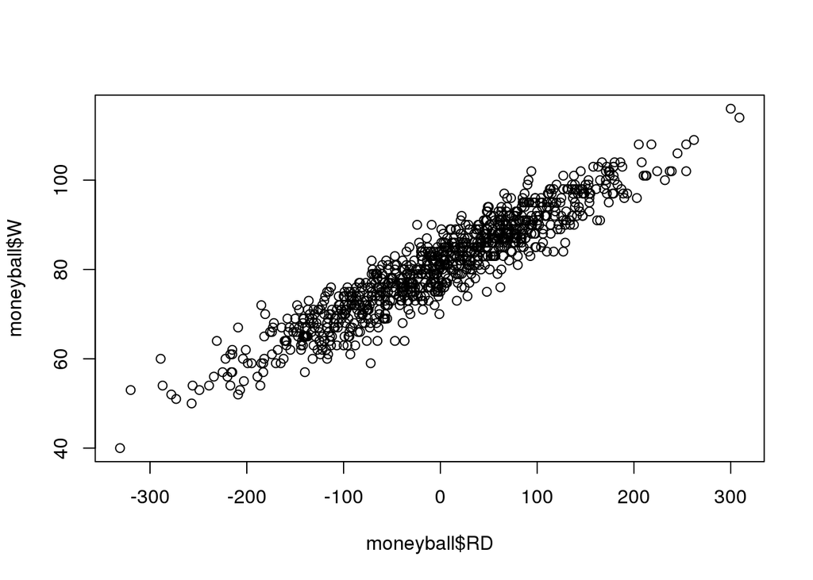

```r
plot(moneyball$RD, moneyball$W)
```

The scatter plot shows as that there’s a very strong linear relationship between these two variables, which is a good sign for the linear regression equation.

Create now the linear regressino model, which we’ll call WinsReg

```r
WinsReg = lm(W ~ RD, data=moneyball)
summary(WinsReg)
```

```
##
## Call:
## lm(formula = W ~ RD, data = moneyball)
##
## Residuals:
##      Min       1Q   Median       3Q      Max
## -14.2662  -2.6509   0.1234   2.9364  11.6570
##
## Coefficients:
##              Estimate Std. Error t value Pr(>|t|)
## (Intercept) 80.881375   0.131157  616.67   <2e-16 ***
## RD           0.105766   0.001297   81.55   <2e-16 ***
## ---
## Signif. codes:  0 '***' 0.001 '**' 0.01 '*' 0.05 '.' 0.1 ' ' 1
##
## Residual standard error: 3.939 on 900 degrees of freedom
## Multiple R-squared:  0.8808, Adjusted R-squared:  0.8807
## F-statistic:  6651 on 1 and 900 DF,  p-value: < 2.2e-16
```

RD is very significant and the R-squared is 0.88. This is a strong model to predict wins using difference between runs scored and runs allowed.

From the model we can extract the equation: $W = 80.8814 + 0.1058*RD$.

We want Wins to be greater than or equal to 95: $W \geq 95$.

```r
RD = (95 - 80.8814) / 0.1058
RD
```

```
## [1] 133.4461
```

This is very close to the claim made in Moneyball that a team needs to score at least 135 more runs than they allow to win at least 95 games.

### Predict runs

Now, we need to know how many runs a team will score, which we’ll show can be predicted with batting statistics, and how many runs a team will allow, wich can be predicted using fielding and pitching statistics.

The Oakland A’s were interested in answering the question: how does a team score more runs? They discoverd two particular baseball statistics: on-base percentage, OBP, and slugging percentage, SLG.

- On-base percentage is the percentage of time a player gets on base, including walks.
- Slugging percentage measures how far a player gets around the bases on his turn and measures the power a hitter.

Most baseball teams and experts focused on batting average, which measures how often a hitter gets on base by hitting the ball.

The Oakland A’s claimed that on-base percentage was the most important statistic for predicting runs.

Let’s see if we can use linear regression in R, to verify wich baseball statistic are important for predicting runs scored.

```r
RunsReg = lm(RS ~ OBP + SLG + BA, data=moneyball)
summary(RunsReg)
```

```
##
## Call:
## lm(formula = RS ~ OBP + SLG + BA, data = moneyball)
##
## Residuals:
##     Min      1Q  Median      3Q     Max
## -70.941 -17.247  -0.621  16.754  90.998
##
## Coefficients:
##             Estimate Std. Error t value Pr(>|t|)
## (Intercept)  -788.46      19.70 -40.029  < 2e-16 ***
## OBP          2917.42     110.47  26.410  < 2e-16 ***
## SLG          1637.93      45.99  35.612  < 2e-16 ***
## BA           -368.97     130.58  -2.826  0.00482 **
## ---
## Signif. codes:  0 '***' 0.001 '**' 0.01 '*' 0.05 '.' 0.1 ' ' 1
##
## Residual standard error: 24.69 on 898 degrees of freedom
## Multiple R-squared:  0.9302, Adjusted R-squared:   0.93
## F-statistic:  3989 on 3 and 898 DF,  p-value: < 2.2e-16
```

We can see that all our independent variable are significant and the R-squared is 0.93. But if we look closer at the coefficients, we can see that the coefficient for batting average is negative.

This implies that, a team with a lower batting average will score more runs, which is a little counterintuitive

This seems a case of multicollinearity. These three hitting statistics are highly correlated.

Let’s try removing batting average to see what happens to our model.

```r
RunsReg = lm(RS ~ OBP + SLG, data=moneyball)
summary(RunsReg)
```

```
##
## Call:
## lm(formula = RS ~ OBP + SLG, data = moneyball)
##
## Residuals:
##     Min      1Q  Median      3Q     Max
## -70.838 -17.174  -1.108  16.770  90.036
##
## Coefficients:
##             Estimate Std. Error t value Pr(>|t|)
## (Intercept)  -804.63      18.92  -42.53   <2e-16 ***
## OBP          2737.77      90.68   30.19   <2e-16 ***
## SLG          1584.91      42.16   37.60   <2e-16 ***
## ---
## Signif. codes:  0 '***' 0.001 '**' 0.01 '*' 0.05 '.' 0.1 ' ' 1
##
## Residual standard error: 24.79 on 899 degrees of freedom
## Multiple R-squared:  0.9296, Adjusted R-squared:  0.9294
## F-statistic:  5934 on 2 and 899 DF,  p-value: < 2.2e-16
```

We can see that our independent variables are still very significant, the coefficients are both positive and the R-squared is still about 0.93.

This model is simpler, with only two independent variables and has about the same R-squared.

If we compare the two coefficient, we sse that on-base percentage has a larger coefficient than slugging percentage. This tells us that on-base percentage is probabily worth more than slugging percentage.

So the claims made in Moneyball are verified.

We can create a very similar model to predict runs allowed. This model uses pitching statistics: opponents on-base percentage, OOBP, and opponents slugging percentage, OSLG.

```r
RunsAllReg = lm(RA ~ OOBP + OSLG, data=moneyball)
summary(RunsAllReg)
```

```
##
## Call:
## lm(formula = RA ~ OOBP + OSLG, data = moneyball)
##
## Residuals:
##     Min      1Q  Median      3Q     Max
## -82.397 -15.178  -0.129  17.679  60.955
##
## Coefficients:
##             Estimate Std. Error t value Pr(>|t|)
## (Intercept)  -837.38      60.26 -13.897  < 2e-16 ***
## OOBP         2913.60     291.97   9.979 4.46e-16 ***
## OSLG         1514.29     175.43   8.632 2.55e-13 ***
## ---
## Signif. codes:  0 '***' 0.001 '**' 0.01 '*' 0.05 '.' 0.1 ' ' 1
##
## Residual standard error: 25.67 on 87 degrees of freedom
##   (812 observations deleted due to missingness)
## Multiple R-squared:  0.9073, Adjusted R-squared:  0.9052
## F-statistic: 425.8 on 2 and 87 DF,  p-value: < 2.2e-16
```

The key message here is that simple models, using only a couple independent variables, can be constructed to answer some of the most important questions in baseball.

### Using the Models to Make Predictions

We would like to predict before the season starts how many games the 2002 Oakland A’s will win.

To do this, we first have to predict how many runs the team will score and how many runs they will allow. These models use team statistics. However, when we are predicting for the 2002 Oakland A’s before the season has occurred, the team is probabily different than it was the year before.

So we don’t know the team statistic. But we can estimate these statistics using past player performance assuming that past performance correlates with future performance and that will be few injuries during the season.

Let’s start by making a prediction for runs scored.

At the beginning of the 2002 season, the Oakland A’s had 24 batters on their roster. We can estimate that team on-base percentage will be about 0.339 and team slugging percentage will be about 0.430.

Using the previous model, we predict that the 2002 Oakland A’s will score about 805 runs.

Similarly, we can make a prediction for runs allowed. At the beginning of the 2002 season, the Oakland A’s had 17 pitchers on their roster. Using the 2001 regular season statistics for these players, we can estimate that team opponent on-base percentage will be about 0.307 and team opponent slugging percentage will be about 0.373.

Using the previous model, we predict that he 2002 Oakland A’s will allow 622 runs.

We can plug the difference 805-622 in the previous model and predict that the A’s will win 100 games in 2002.

These predictions are similar to Paul DePodesta’s predictions. And it turns out that the 2002 Oakland A’s actually scored 800 and allowed 653 runs. And they won 103 games.

These predictions show us that by using publicly available data and simple analytics, we can predict very close to what actually happened before the season even started.